# Starbucks Capstone Challenge

### Introduction

In this project, we analyse customer behaviour on the Starbucks rewards mobile app to understand which demographic groups respond best to different types of offers. We combine transaction, demographic, and offer data to provide insights on how Starbucks can effectively target their marketing campaigns. By leveraging this information, Starbucks can optimize its offers and improve customer engagement. Problem Statement Our goal is to predict which offers are likely to be completed by customers based on their demographic information and the characteristics of the offers. We will use linear regression to model the relationship between these variables and the probability of offer completion. This analysis will help Starbucks understand the effectiveness of their offers and tailor their marketing strategy accordingly.

# Data Sets

The data is contained in three files:

- portfolio.json - containing offer ids and meta data about each offer (duration, type, etc.)
- profile.json - demographic data for each customer
- transcript.json - records for transactions, offers received, offers viewed, and offers completed

Here is the schema and explanation of each variable in the files:

**portfolio.json**

- id (string) - offer id
- offer_type (string) - type of offer ie BOGO, discount, informational
- difficulty (int) - minimum required spend to complete an offer
- reward (int) - reward given for completing an offer
- duration (int) - time for offer to be open, in days
- channels (list of strings)

**profile.json**

- age (int) - age of the customer
- became_member_on (int) - date when customer created an app account
- gender (str) - gender of the customer (note some entries contain 'O' for other rather than M or F)
- id (str) - customer id
- income (float) - customer's income

**transcript.json**

- event (str) - record description (ie transaction, offer received, offer viewed, etc.)
- person (str) - customer id
- time (int) - time in hours since start of test. The data begins at time t=0
- value - (dict of strings) - either an offer id or transaction amount depending on the record

```python
    import pandas as pd
    import numpy as np
    import math
    import json
    import matplotlib.pyplot as plt
    import seaborn as sns
    %matplotlib inline

    from sklearn.model_selection import train_test_split
    from sklearn.preprocessing import StandardScaler


# read in the json files
portfolio = pd.read_json('data/portfolio.json', orient='records', lines=True)
profile = pd.read_json('data/profile.json', orient='records', lines=True)
transcript = pd.read_json('data/transcript.json', orient='records', lines=True)
```

# Data Assessment

```python
portfolio.head(10)
```

|  | reward | channels | difficulty | duration | offer_type | id |
| --- | --- | --- | --- | --- | --- | --- |
| 0 | 10 | [email, mobile, social] | 10 | 7 | bogo | ae264e3637204a6fb9bb56bc8210ddfd |
| 1 | 10 | [web, email, mobile, social] | 10 | 5 | bogo | 4d5c57ea9a6940dd891ad53e9dbe8da0 |
| 2 | 0 | [web, email, mobile] | 0 | 4 | informational | 3f207df678b143eea3cee63160fa8bed |
| 3 | 5 | [web, email, mobile] | 5 | 7 | bogo | 9b98b8c7a33c4b65b9aebfe6a799e6d9 |
| 4 | 5 | [web, email] | 20 | 10 | discount | 0b1e1539f2cc45b7b9fa7c272da2e1d7 |
| 5 | 3 | [web, email, mobile, social] | 7 | 7 | discount | 2298d6c36e964ae4a3e7e9706d1fb8c2 |
| 6 | 2 | [web, email, mobile, social] | 10 | 10 | discount | fafdcd668e3743c1bb461111dcafc2a4 |
| 7 | 0 | [email, mobile, social] | 0 | 3 | informational | 5a8bc65990b245e5a138643cd4eb9837 |
| 8 | 5 | [web, email, mobile, social] | 5 | 5 | bogo | f19421c1d4aa40978ebb69ca19b0e20d |
| 9 | 2 | [web, email, mobile] | 10 | 7 | discount | 2906b810c7d4411798c6938adc9daaa5 |

```python
portfolio.info()
```

```
<class 'pandas.core.frame.DataFrame'>
RangeIndex: 10 entries, 0 to 9
Data columns (total 6 columns):
 #   Column      Non-Null Count  Dtype
---  ------      --------------  -----
 0   reward      10 non-null     int64
 1   channels    10 non-null     object
 2   difficulty  10 non-null     int64
 3   duration    10 non-null     int64
 4   offer_type  10 non-null     object
 5   id          10 non-null     object
dtypes: int64(3), object(3)
memory usage: 608.0+ bytes
```

```python
profile.info()
```

```
<class 'pandas.core.frame.DataFrame'>
RangeIndex: 17000 entries, 0 to 16999
Data columns (total 5 columns):
 #   Column            Non-Null Count  Dtype
---  ------            --------------  -----
 0   gender            14825 non-null  object
 1   age               17000 non-null  int64
 2   id                17000 non-null  object
 3   became_member_on  17000 non-null  int64
 4   income            14825 non-null  float64
dtypes: float64(1), int64(2), object(2)
memory usage: 664.2+ KB
```

```python
profile.head()
```

|  | gender | age | id | became_member_on | income |
| --- | --- | --- | --- | --- | --- |
| 0 | None | 118 | 68be06ca386d4c31939f3a4f0e3dd783 | 20170212 | NaN |
| 1 | F | 55 | 0610b486422d4921ae7d2bf64640c50b | 20170715 | 112000.0 |
| 2 | None | 118 | 38fe809add3b4fcf9315a9694bb96ff5 | 20180712 | NaN |
| 3 | F | 75 | 78afa995795e4d85b5d9ceeca43f5fef | 20170509 | 100000.0 |
| 4 | None | 118 | a03223e636434f42ac4c3df47e8bac43 | 20170804 | NaN |

```python
transcript.info()
```

```
<class 'pandas.core.frame.DataFrame'>
RangeIndex: 306534 entries, 0 to 306533
Data columns (total 4 columns):
 #   Column  Non-Null Count   Dtype
---  ------  --------------   -----
 0   person  306534 non-null  object
 1   event   306534 non-null  object
 2   value   306534 non-null  object
 3   time    306534 non-null  int64
dtypes: int64(1), object(3)
memory usage: 9.4+ MB
```

```python
transcript.head()
```

|  | person | event | value | time |
| --- | --- | --- | --- | --- |
| 0 | 78afa995795e4d85b5d9ceeca43f5fef | offer received | {'offer id': '9b98b8c7a33c4b65b9aebfe6a799e6d9'} | 0 |
| 1 | a03223e636434f42ac4c3df47e8bac43 | offer received | {'offer id': '0b1e1539f2cc45b7b9fa7c272da2e1d7'} | 0 |
| 2 | e2127556f4f64592b11af22de27a7932 | offer received | {'offer id': '2906b810c7d4411798c6938adc9daaa5'} | 0 |
| 3 | 8ec6ce2a7e7949b1bf142def7d0e0586 | offer received | {'offer id': 'fafdcd668e3743c1bb461111dcafc2a4'} | 0 |
| 4 | 68617ca6246f4fbc85e91a2a49552598 | offer received | {'offer id': '4d5c57ea9a6940dd891ad53e9dbe8da0'} | 0 |

```python
# check if transcript events have any mistakes
transcript['event'].unique()
```

```
array(['offer received', 'offer viewed', 'transaction', 'offer completed'],
      dtype=object)
```

```python
transcript['event'].value_counts()
```

```
transaction        138953
offer received      76277
offer viewed        57725
offer completed     33579
Name: event, dtype: int64
```

### Check for missing values

```python
transcript.isnull().sum()
```

```
person    0
event     0
value     0
time      0
dtype: int64
```

```python
profile.isnull().sum()
```

```
gender              2175
age                    0
id                     0
became_member_on       0
income              2175
dtype: int64
```

```python
profile.describe()
```

|  | age | became_member_on | income |
| --- | --- | --- | --- |
| count | 17000.000000 | 1.700000e+04 | 14825.000000 |
| mean | 62.531412 | 2.016703e+07 | 65404.991568 |
| std | 26.738580 | 1.167750e+04 | 21598.299410 |
| min | 18.000000 | 2.013073e+07 | 30000.000000 |
| 25% | 45.000000 | 2.016053e+07 | 49000.000000 |
| 50% | 58.000000 | 2.017080e+07 | 64000.000000 |
| 75% | 73.000000 | 2.017123e+07 | 80000.000000 |
| max | 118.000000 | 2.018073e+07 | 120000.000000 |

The income column seems clean. We can see some extraordinary data in the age column (age 118)

# Data Cleaning

## Cleaning - Profile dataset

Replace age entries > 100 with NaN values. I assume these were incorrect data entries.

```python
profile.sort_values('age', ascending=False).head(5)
```

|  | gender | age | id | became_member_on | income |
| --- | --- | --- | --- | --- | --- |
| 0 | None | 118 | 68be06ca386d4c31939f3a4f0e3dd783 | 20170212 | NaN |
| 3510 | None | 118 | a94d4b0cca4d47128920f66a5286431d | 20180331 | NaN |
| 12484 | None | 118 | b04385001db14fdf87829c6163ae9ddd | 20160727 | NaN |
| 3483 | None | 118 | d4309b7d75174eaa8115f4357b28cd98 | 20170917 | NaN |
| 12458 | None | 118 | c28414b774094421b34abfe44c6d303c | 20180313 | NaN |

```python
profile[profile['age'] == 118]['age'].count()
```

```
2175
```

```python
profile[profile['age'] > 100]['age'].count()
```

```
2180
```

```python
# replace age entries > 100 with NaN values
profile.loc[profile['age'] > 100, 'age'] = np.nan
```

```python
# Test
print(profile[profile['age'] > 100]['age'].count())

# Check if there are any NaN values in the age column
print(profile['age'].isna().sum())
```

```
0
2180
```

Rename id column to 'customer_id'

```python
profile.rename(columns={'id': 'customer_id'}, inplace=True)
```

Convert become_member_on to datetime

```python
profile['became_member_on'] = pd.to_datetime(profile['became_member_on'], format='%Y%m%d')
```

```python
# Test
profile.info()
```

```
<class 'pandas.core.frame.DataFrame'>
RangeIndex: 17000 entries, 0 to 16999
Data columns (total 5 columns):
 #   Column            Non-Null Count  Dtype
---  ------            --------------  -----
 0   gender            14825 non-null  object
 1   age               14820 non-null  float64
 2   customer_id       17000 non-null  object
 3   became_member_on  17000 non-null  datetime64[ns]
 4   income            14825 non-null  float64
dtypes: datetime64[ns](1), float64(2), object(2)
memory usage: 664.2+ KB
```

# Cleaning - Portfolio dataset

Rename id to offer_id

```python
portfolio = portfolio.rename(columns={'id': 'offer_id'})
```

Split the 'channel' column into 4 columns using a lambda function, and finally drop the channels column

```python
# Define a lambda function to split the channels column
split_channels = lambda x: pd.Series([1 if ch in x else 0 for ch in ['web', 'email', 'mobile', 'social']])

# Create new columns for each channel using the lambda function
portfolio[['web', 'email', 'mobile', 'social']] = portfolio['channels'].apply(split_channels)

# Drop the original 'channels' column
portfolio.drop(columns=['channels'], inplace=True)
```

```python
# Test
portfolio.head()
```

|  | reward | difficulty | duration | offer_type | offer_id | web | email | mobile | social |
| --- | --- | --- | --- | --- | --- | --- | --- | --- | --- |
| 0 | 10 | 10 | 7 | bogo | ae264e3637204a6fb9bb56bc8210ddfd | 0 | 1 | 1 | 1 |
| 1 | 10 | 10 | 5 | bogo | 4d5c57ea9a6940dd891ad53e9dbe8da0 | 1 | 1 | 1 | 1 |
| 2 | 0 | 0 | 4 | informational | 3f207df678b143eea3cee63160fa8bed | 1 | 1 | 1 | 0 |
| 3 | 5 | 5 | 7 | bogo | 9b98b8c7a33c4b65b9aebfe6a799e6d9 | 1 | 1 | 1 | 0 |
| 4 | 5 | 20 | 10 | discount | 0b1e1539f2cc45b7b9fa7c272da2e1d7 | 1 | 1 | 0 | 0 |

Convert the 'offer_type' column to categorical datatype

```python
portfolio['offer_type'] = pd.Categorical(portfolio['offer_type'])
```

# Cleaning - Transcript dataset

```python
transcript.tail(10)
```

|  | person | event | value | time |
| --- | --- | --- | --- | --- |
| 306524 | d613ca9c59dd42f497bdbf6178da54a7 | transaction | {'amount': 25.14} | 714 |
| 306525 | eec70ab28af74a22a4aeb889c0317944 | transaction | {'amount': 43.58} | 714 |
| 306526 | 24f56b5e1849462093931b164eb803b5 | transaction | {'amount': 22.64} | 714 |
| 306527 | 24f56b5e1849462093931b164eb803b5 | offer completed | {'offer_id': 'fafdcd668e3743c1bb461111dcafc2a4... | 714 |
| 306528 | 5ca2620962114246ab218fc648eb3934 | transaction | {'amount': 2.2} | 714 |
| 306529 | b3a1272bc9904337b331bf348c3e8c17 | transaction | {'amount': 1.59} | 714 |
| 306530 | 68213b08d99a4ae1b0dcb72aebd9aa35 | transaction | {'amount': 9.53} | 714 |
| 306531 | a00058cf10334a308c68e7631c529907 | transaction | {'amount': 3.61} | 714 |
| 306532 | 76ddbd6576844afe811f1a3c0fbb5bec | transaction | {'amount': 3.53} | 714 |
| 306533 | c02b10e8752c4d8e9b73f918558531f7 | transaction | {'amount': 4.05} | 714 |

Rename person column to customer_id

```python
transcript = transcript.rename(columns={'person': 'customer_id'})
```

Convert 'time' column from hours to days, which makes it consistent with the portfolio dataset

```python
transcript['time'] = transcript['time'] / 24
```

Split the 'value' column into separate columns for 'offer_id', 'amount', and 'reward', depending on the event type. This will make it easier to analyze the data for each event type.

```python
# define a function to extract amount, order_id, and rewards from the value column
def extract_value(row):
    if 'amount' in row:
        return [row['amount'], np.nan, np.nan]
    elif 'offer_id' in row:
        order_id = row['offer_id'] if 'offer_id' in row else row['offer id']
        return [np.nan, order_id, row.get('reward')]
    else:
        return [np.nan, np.nan, row.get('reward')]

# apply the function to the value column to create new columns
transcript[['amount', 'offer_id', 'rewards']] = pd.DataFrame(transcript['value'].apply(lambda x: extract_value(x)).tolist(), index=transcript.index)

# drop the original value column
transcript.drop(columns=['value'], inplace=True)

# check
transcript.head()
```

|  | customer_id | event | time | amount | offer_id | rewards |
| --- | --- | --- | --- | --- | --- | --- |
| 0 | 78afa995795e4d85b5d9ceeca43f5fef | offer received | 0.0 | NaN | NaN | NaN |
| 1 | a03223e636434f42ac4c3df47e8bac43 | offer received | 0.0 | NaN | NaN | NaN |
| 2 | e2127556f4f64592b11af22de27a7932 | offer received | 0.0 | NaN | NaN | NaN |
| 3 | 8ec6ce2a7e7949b1bf142def7d0e0586 | offer received | 0.0 | NaN | NaN | NaN |
| 4 | 68617ca6246f4fbc85e91a2a49552598 | offer received | 0.0 | NaN | NaN | NaN |

Split event column to new columns for each event and then drop event column

```python
# Define a lambda function to split the event column
split_event = lambda x: pd.Series([1 if x == 'offer received' else 0,
                                   1 if x == 'offer viewed' else 0,
                                   1 if x == 'offer completed' else 0,
                                   1 if x == 'transaction' else 0])

# Create new columns for each event using the lambda function
transcript[['offer_received', 'offer_viewed', 'offer_completed', 'transaction']] = transcript['event'].apply(split_event)

# Drop the original 'event' column
transcript.drop(columns=['event'], inplace=True)
```

```python
# Test
transcript.sample(5)
```

|  | customer_id | time | amount | offer_id | rewards | offer_received | offer_viewed | offer_completed | transaction |
| --- | --- | --- | --- | --- | --- | --- | --- | --- | --- |
| 251040 | 3355c0c60b6d4ba4bf31d83f47af9dab | 24.00 | NaN | NaN | NaN | 1 | 0 | 0 | 0 |
| 297965 | c224c3eb8ca34ea0b5c5f2981cb4085f | 28.25 | 24.38 | NaN | NaN | 0 | 0 | 0 | 1 |
| 232438 | 3834df40d4f544f186de0e1149511127 | 22.25 | 19.31 | NaN | NaN | 0 | 0 | 0 | 1 |
| 205511 | 7a88c1b8eb654e98b4595c642193d50d | 21.00 | NaN | NaN | NaN | 1 | 0 | 0 | 0 |
| 35564 | b94c7601b17b41609daa2e3e56c3f53d | 3.00 | 3.42 | NaN | NaN | 0 | 0 | 0 | 1 |

Drop Rewards column

```python
transcript.drop('rewards', axis=1, inplace=True)
```

Check for duplicates

```python
transcript.duplicated().sum()
```

```
397
```

Drop duplicates

```python
transcript.drop_duplicates(inplace = True)
```

```python
transcript.sample(20)
```

|  | customer_id | time | amount | offer_id | offer_received | offer_viewed | offer_completed | transaction |
| --- | --- | --- | --- | --- | --- | --- | --- | --- |
| 11963 | fdc10e59f04044159c5ddd72d76b1955 | 0.00 | NaN | NaN | 1 | 0 | 0 | 0 |
| 42250 | c2f2e7f440bc45738b2fbea9b58217bd | 4.25 | 12.08 | NaN | 0 | 0 | 0 | 1 |
| 76902 | 6a8b0facbdf34e45bbf6d1f82fa6fc79 | 7.75 | 30.30 | NaN | 0 | 0 | 0 | 1 |
| 181323 | 2a396eb0dba0431abd59e701ebe28cb9 | 18.25 | 10.23 | NaN | 0 | 0 | 0 | 1 |
| 144695 | 957c78e7515f4176a1fc3cebcaa9a020 | 16.00 | 4.92 | NaN | 0 | 0 | 0 | 1 |
| 257158 | 543ea0deb4dc4234ac6f5237eedffc9f | 24.00 | NaN | NaN | 1 | 0 | 0 | 0 |
| 199578 | 577dbfb64274452ab6b330346f7fdcf0 | 20.50 | 2.41 | NaN | 0 | 0 | 0 | 1 |
| 166616 | 3a506f9fe2c04048829ef0fc3fa49cc8 | 17.00 | 17.18 | NaN | 0 | 0 | 0 | 1 |
| 102219 | 577dbfb64274452ab6b330346f7fdcf0 | 11.75 | NaN | 2298d6c36e964ae4a3e7e9706d1fb8c2 | 0 | 0 | 1 | 0 |
| 194246 | ecffdade856446168b87a147bc8d2342 | 19.75 | 15.84 | NaN | 0 | 0 | 0 | 1 |
| 78789 | f2ac47ad6a874a10b85490a42cb23d76 | 8.00 | NaN | NaN | 0 | 1 | 0 | 0 |
| 266910 | e311b9067f484ff8a11bc16c6c234465 | 24.50 | 11.82 | NaN | 0 | 0 | 0 | 1 |
| 133138 | 4806e4b0352b40b7ac0bcb8163875194 | 14.75 | 2.56 | NaN | 0 | 0 | 0 | 1 |
| 238029 | cdd7e7d676644a08bf5647f6a500f257 | 23.00 | NaN | 0b1e1539f2cc45b7b9fa7c272da2e1d7 | 0 | 0 | 1 | 0 |
| 43253 | 25ff4f5d2d354e599980dc5fd3f50021 | 4.50 | NaN | fafdcd668e3743c1bb461111dcafc2a4 | 0 | 0 | 1 | 0 |
| 103589 | b8baee8a55b24b2b9d91b854b1d079f9 | 12.00 | 17.06 | NaN | 0 | 0 | 0 | 1 |
| 93504 | 81a3bc296c884642b2b3b7db8b39d412 | 10.00 | 1.59 | NaN | 0 | 0 | 0 | 1 |
| 66721 | e46283405b094b62806e05f24c5f0304 | 7.00 | NaN | NaN | 0 | 1 | 0 | 0 |
| 184205 | 74429a966afd4d5baa2c31700c782e1b | 18.50 | NaN | NaN | 0 | 1 | 0 | 0 |
| 239088 | fff29fb549084123bd046dbc5ceb4faa | 23.00 | 32.57 | NaN | 0 | 0 | 0 | 1 |

Check for negative values in the amount column

```python
transcript[transcript['amount'] < 0]
```

|  | customer_id | time | amount | offer_id | offer_received | offer_viewed | offer_completed | transaction |
| --- | --- | --- | --- | --- | --- | --- | --- | --- |

## Merge all datasets together

```python
portfolio.head()
```

|  | reward | difficulty | duration | offer_type | offer_id | web | email | mobile | social |
| --- | --- | --- | --- | --- | --- | --- | --- | --- | --- |
| 0 | 10 | 10 | 7 | bogo | ae264e3637204a6fb9bb56bc8210ddfd | 0 | 1 | 1 | 1 |
| 1 | 10 | 10 | 5 | bogo | 4d5c57ea9a6940dd891ad53e9dbe8da0 | 1 | 1 | 1 | 1 |
| 2 | 0 | 0 | 4 | informational | 3f207df678b143eea3cee63160fa8bed | 1 | 1 | 1 | 0 |
| 3 | 5 | 5 | 7 | bogo | 9b98b8c7a33c4b65b9aebfe6a799e6d9 | 1 | 1 | 1 | 0 |
| 4 | 5 | 20 | 10 | discount | 0b1e1539f2cc45b7b9fa7c272da2e1d7 | 1 | 1 | 0 | 0 |

```python
# Merge transcript and portfolio datasets with a left-join on offer_id
tp = transcript.merge(portfolio, how = 'left', on = 'offer_id')

# Merge the new tp and profile dataset with an inner-join on customer_id
dfm = tp.merge(profile, how = 'inner', on = 'customer_id')

dfm.head()
```

|  | customer_id | time | amount | offer_id | offer_received | offer_viewed | offer_completed | transaction | reward | difficulty | duration | offer_type | web | email | mobile | social | gender | age | became_member_on | income |
| --- | --- | --- | --- | --- | --- | --- | --- | --- | --- | --- | --- | --- | --- | --- | --- | --- | --- | --- | --- | --- |
| 0 | 78afa995795e4d85b5d9ceeca43f5fef | 0.00 | NaN | NaN | 1 | 0 | 0 | 0 | NaN | NaN | NaN | NaN | NaN | NaN | NaN | NaN | F | 75.0 | 2017-05-09 | 100000.0 |
| 1 | 78afa995795e4d85b5d9ceeca43f5fef | 0.25 | NaN | NaN | 0 | 1 | 0 | 0 | NaN | NaN | NaN | NaN | NaN | NaN | NaN | NaN | F | 75.0 | 2017-05-09 | 100000.0 |
| 2 | 78afa995795e4d85b5d9ceeca43f5fef | 5.50 | 19.89 | NaN | 0 | 0 | 0 | 1 | NaN | NaN | NaN | NaN | NaN | NaN | NaN | NaN | F | 75.0 | 2017-05-09 | 100000.0 |
| 3 | 78afa995795e4d85b5d9ceeca43f5fef | 5.50 | NaN | 9b98b8c7a33c4b65b9aebfe6a799e6d9 | 0 | 0 | 1 | 0 | 5.0 | 5.0 | 7.0 | bogo | 1.0 | 1.0 | 1.0 | 0.0 | F | 75.0 | 2017-05-09 | 100000.0 |
| 4 | 78afa995795e4d85b5d9ceeca43f5fef | 6.00 | 17.78 | NaN | 0 | 0 | 0 | 1 | NaN | NaN | NaN | NaN | NaN | NaN | NaN | NaN | F | 75.0 | 2017-05-09 | 100000.0 |

```python
dfm.info()
```

```
<class 'pandas.core.frame.DataFrame'>
Int64Index: 306137 entries, 0 to 306136
Data columns (total 20 columns):
 #   Column            Non-Null Count   Dtype
---  ------            --------------   -----
 0   customer_id       306137 non-null  object
 1   time              306137 non-null  float64
 2   amount            138953 non-null  float64
 3   offer_id          33182 non-null   object
 4   offer_received    306137 non-null  int64
 5   offer_viewed      306137 non-null  int64
 6   offer_completed   306137 non-null  int64
 7   transaction       306137 non-null  int64
 8   reward            33182 non-null   float64
 9   difficulty        33182 non-null   float64
 10  duration          33182 non-null   float64
 11  offer_type        33182 non-null   category
 12  web               33182 non-null   float64
 13  email             33182 non-null   float64
 14  mobile            33182 non-null   float64
 15  social            33182 non-null   float64
 16  gender            272388 non-null  object
 17  age               272290 non-null  float64
 18  became_member_on  306137 non-null  datetime64[ns]
 19  income            272388 non-null  float64
dtypes: category(1), datetime64[ns](1), float64(11), int64(4), object(3)
memory usage: 47.0+ MB
```

# Explore our master dataset with visualisations

Offer Types Distribution

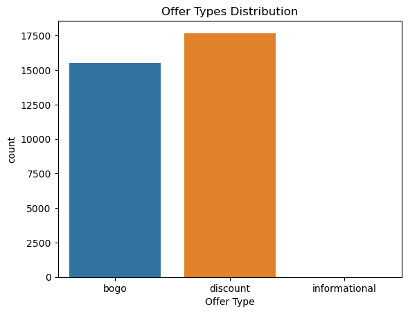

```python
sns.countplot(x='offer_type', data=dfm)
plt.title('Offer Types Distribution')
plt.xlabel('Offer Type')
plt.show()
```

Age Distribution of our Customers

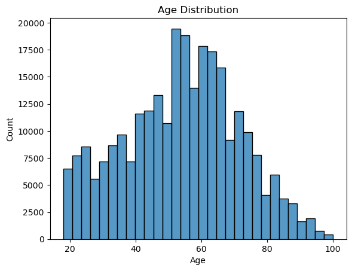

```python
sns.histplot(dfm['age'], bins=30)
plt.title('Age Distribution')
plt.xlabel('Age')
plt.show()
```

Heatmap of Correlation

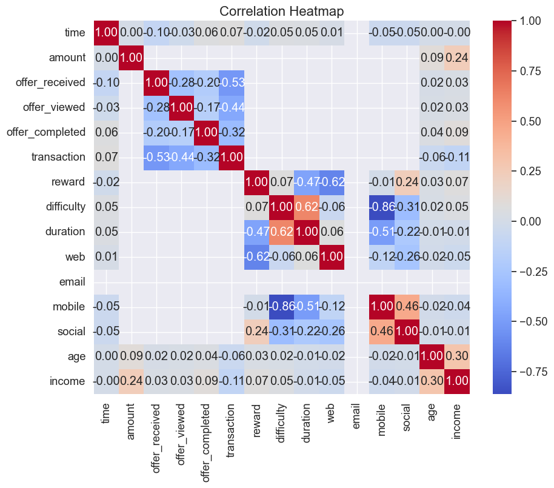

```python
plt.figure(figsize=(10, 8))
sns.set(font_scale=1.2)
sns.heatmap(dfm.corr(), annot=True, cmap='coolwarm', fmt='.2f')
plt.title("Correlation Heatmap", fontsize=16)
plt.show()
```

The heatmap isn't as insightful as I thought it'd be. Duration and difficulty, Social and mobile, and age and income have a positive correlation. This isn't surprising, but also not very insightful for our analysis.

Boxplot of Income

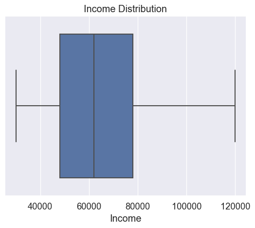

```python
sns.boxplot(x='income', data=dfm)
plt.title('Income Distribution')
plt.xlabel('Income')
plt.show()
```

The boxplot depicting the distribution of income reveals a range that appears to be in line with what one might anticipate for a typical Starbucks customer base. This observation is not particularly surprising, as it aligns with the general expectations for the income levels of individuals who frequent Starbucks.

Profile Income Distribution

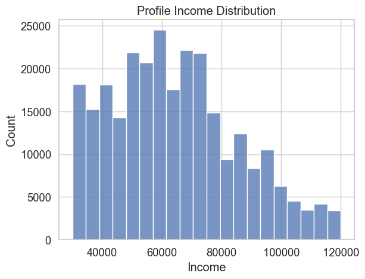

```python
sns.set_style('whitegrid')
sns.histplot(dfm['income'].dropna(), kde=False, bins=20)
plt.title('Profile Income Distribution')
plt.xlabel('Income')
plt.ylabel('Count')
plt.show()
```

Bar Plot of Gender

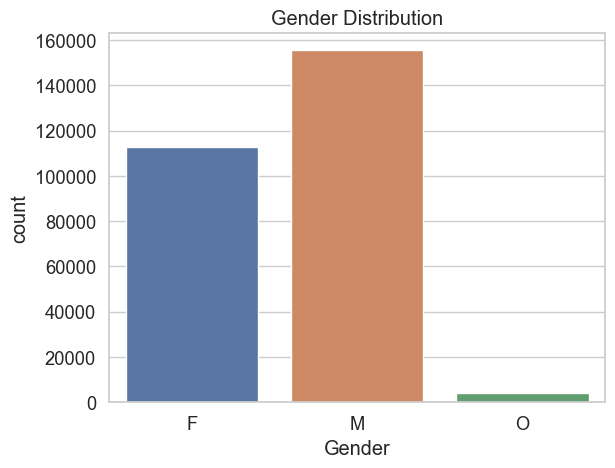

```python
sns.countplot(x='gender', data=dfm)
plt.title('Gender Distribution')
plt.xlabel('Gender')
plt.show()
```

```python
# Debugging
class_distribution = dfm['offer_completed'].value_counts()
print(class_distribution)
```

```
0    272955
1     33182
Name: offer_completed, dtype: int64
```

Distribution of Offers by Gender

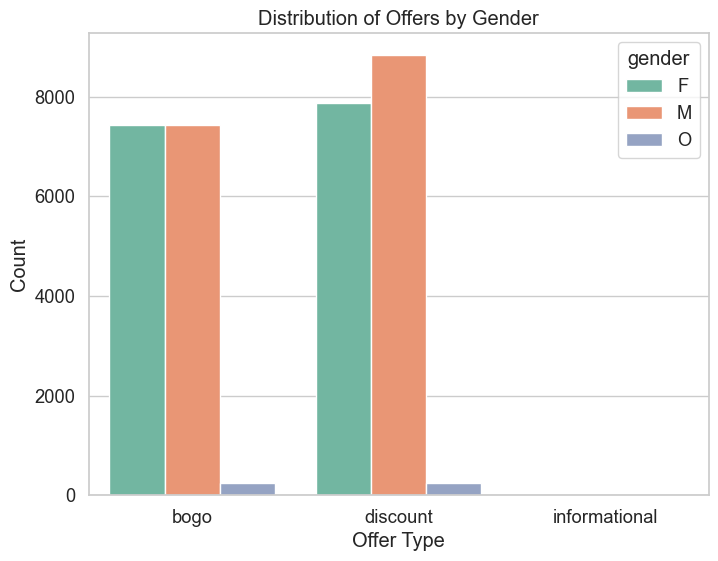

```python
plt.figure(figsize=(8, 6))
sns.countplot(x="offer_type", hue="gender", data=dfm, palette="Set2")
plt.title("Distribution of Offers by Gender")
plt.xlabel("Offer Type")
plt.ylabel("Count")
plt.show()
```

Relationship between Income and Total Amount Spent by Customers

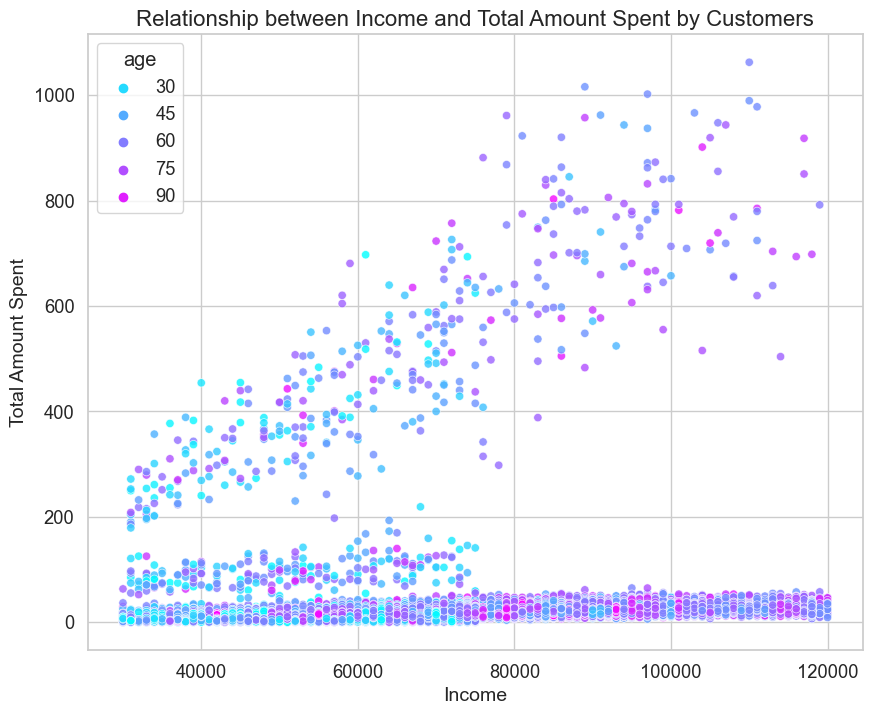

```python
sns.set_style('whitegrid')
plt.figure(figsize=(10,8))

sns.scatterplot(data=dfm, x='income', y='amount', hue='age', palette='cool', alpha=0.8)

plt.title('Relationship between Income and Total Amount Spent by Customers', fontsize=16)
plt.xlabel('Income', fontsize=14)
plt.ylabel('Total Amount Spent', fontsize=14)

plt.show()
```

# Pre-Modeling preparation

### Dealing with missing values

```python
# Check for missing values
dfm.isnull().sum()
```

```
customer_id              0
time                     0
amount              167184
offer_id            272955
offer_received           0
offer_viewed             0
offer_completed          0
transaction              0
reward              272955
difficulty          272955
duration            272955
offer_type          272955
web                 272955
email               272955
mobile              272955
social              272955
gender               33749
age                  33847
became_member_on         0
income               33749
dtype: int64
```

To deal with missing values appropriately, we'll do the following:

1. Fill the rows with 0 where the amount and income columns are missing since they are important variables for our analysis.
2. Fill missing values in the gender column with the mode (most common value).
3. Fill missing values in the reward, difficulty, duration, web, email, mobile, and social columns with 0s since missing values here imply that the customer did not receive an offer.

```python
# Debugging
class_distribution = dfm['offer_completed'].value_counts()
print(class_distribution)
```

```
0    272955
1     33182
Name: offer_completed, dtype: int64
```

```python
# fill missing gender values with mode
dfm['gender'].fillna(dfm['gender'].mode()[0], inplace=True)

# fill missing values in offer-related columns with 0
cols_to_fill = ['reward', 'difficulty', 'duration', 'web', 'email', 'mobile', 'social']
dfm[cols_to_fill] = dfm[cols_to_fill].fillna(0)
```

```python
# Debugging
class_distribution = dfm['offer_completed'].value_counts()
print(class_distribution)
```

```
0    272955
1     33182
Name: offer_completed, dtype: int64
```

```python
# Test
dfm.isnull().sum()
```

```
customer_id              0
time                     0
amount              167184
offer_id            272955
offer_received           0
offer_viewed             0
offer_completed          0
transaction              0
reward                   0
difficulty               0
duration                 0
offer_type          272955
web                      0
email                    0
mobile                   0
social                   0
gender                   0
age                  33847
became_member_on         0
income               33749
dtype: int64
```

```python
# Fill offer_id and offer_type with 0
dfm['offer_id'].fillna(value=np.nan, inplace=True)
dfm['offer_type'].fillna(value=np.nan, inplace=True)
```

Create year column by extracting the year

```python
dfm['year'] = dfm['became_member_on'].dt.year
```

```python
# Test
dfm.head()
```

|  | customer_id | time | amount | offer_id | offer_received | offer_viewed | offer_completed | transaction | reward | difficulty | ... | offer_type | web | email | mobile | social | gender | age | became_member_on | income | year |
| --- | --- | --- | --- | --- | --- | --- | --- | --- | --- | --- | --- | --- | --- | --- | --- | --- | --- | --- | --- | --- | --- |
| 0 | 78afa995795e4d85b5d9ceeca43f5fef | 0.00 | NaN | NaN | 1 | 0 | 0 | 0 | 0.0 | 0.0 | ... | NaN | 0.0 | 0.0 | 0.0 | 0.0 | F | 75.0 | 2017-05-09 | 100000.0 | 2017 |
| 1 | 78afa995795e4d85b5d9ceeca43f5fef | 0.25 | NaN | NaN | 0 | 1 | 0 | 0 | 0.0 | 0.0 | ... | NaN | 0.0 | 0.0 | 0.0 | 0.0 | F | 75.0 | 2017-05-09 | 100000.0 | 2017 |
| 2 | 78afa995795e4d85b5d9ceeca43f5fef | 5.50 | 19.89 | NaN | 0 | 0 | 0 | 1 | 0.0 | 0.0 | ... | NaN | 0.0 | 0.0 | 0.0 | 0.0 | F | 75.0 | 2017-05-09 | 100000.0 | 2017 |
| 3 | 78afa995795e4d85b5d9ceeca43f5fef | 5.50 | NaN | 9b98b8c7a33c4b65b9aebfe6a799e6d9 | 0 | 0 | 1 | 0 | 5.0 | 5.0 | ... | bogo | 1.0 | 1.0 | 1.0 | 0.0 | F | 75.0 | 2017-05-09 | 100000.0 | 2017 |
| 4 | 78afa995795e4d85b5d9ceeca43f5fef | 6.00 | 17.78 | NaN | 0 | 0 | 0 | 1 | 0.0 | 0.0 | ... | NaN | 0.0 | 0.0 | 0.0 | 0.0 | F | 75.0 | 2017-05-09 | 100000.0 | 2017 |

5 rows × 21 columns

Convert the 'gender' column from categorical values to numerical values that can be used in machine learning models

```python
dfm['gender_num'] = dfm.gender.apply(lambda x: 1 if x == 'F' else 2 if (x=='M') else 3 if x == 'O' else np.nan)
```

Finally, create new dataframe for modeling now

```python
# Create a new dataframe for analysis
df_analysis = dfm.copy()

# Select desired columns for analysis
df_analysis = df_analysis[['time', 'amount', 'offer_completed', 'reward',
                           'difficulty', 'age', 'income', 'gender_num', 'year']]
```

```python
df_analysis.head()
```

|  | time | amount | offer_completed | reward | difficulty | age | income | gender_num | year |
| --- | --- | --- | --- | --- | --- | --- | --- | --- | --- |
| 0 | 0.00 | NaN | 0 | 0.0 | 0.0 | 75.0 | 100000.0 | 1 | 2017 |
| 1 | 0.25 | NaN | 0 | 0.0 | 0.0 | 75.0 | 100000.0 | 1 | 2017 |
| 2 | 5.50 | 19.89 | 0 | 0.0 | 0.0 | 75.0 | 100000.0 | 1 | 2017 |
| 3 | 5.50 | NaN | 1 | 5.0 | 5.0 | 75.0 | 100000.0 | 1 | 2017 |
| 4 | 6.00 | 17.78 | 0 | 0.0 | 0.0 | 75.0 | 100000.0 | 1 | 2017 |

```python
# Final check for missing values
df_analysis.isnull().sum()
```

```
time                    0
amount             167184
offer_completed         0
reward                  0
difficulty              0
age                 33847
income              33749
gender_num              0
year                    0
dtype: int64
```

I'll have to fill all entries of NaN in amount, age, and income with 0. I tried to drop them first, but this would drop all offer_completed rows with 1, and make the following modeling obsolete. These could also be data entry mistakes.

```python
# Finally, fill all NaN with 0
df_analysis.fillna(0, inplace = True)
```

```python
# Final check for missing values
df_analysis.isnull().sum()
```

```
time               0
amount             0
offer_completed    0
reward             0
difficulty         0
age                0
income             0
gender_num         0
year               0
dtype: int64
```

# ML Algorithms Considerations

A Linear Regression could be appropriate for predicting the amount spent by customers or the probability of offer completion. Additionally, decision tree-based algorithms such as Random Forest Classifier or Gradient Boosted Trees could be appropriate for predicting whether a customer will complete an offer or not based on the offer characteristics and customer demographics.

# Next Steps

Next steps for building a Linear Regression:

1. Split the data into training and testing sets
2. Scale the numerical features in the training and testing sets using a scaler
3. Train the Linear Regression model on the training set
4. Test the Linear Regression model on the testing set and evaluate its performance using metrics such as R-squared and mean squared error (MSE)
1. Split the data into training and testing sets. Split the data into training and testing sets, with 80% of the data used for training and 20% used for testing. The target variable, offer_completed, is dropped from the feature matrix X and stored in its own variable y. The random_state parameter ensures that the split is reproducible.

```python
X = df_analysis.drop('offer_completed', axis=1)
y = df_analysis['offer_completed']

X_train, X_test, y_train, y_test = train_test_split(X, y, test_size=0.2, random_state=42)
```

2. Scale the numerical features in the training and testing sets using a StandardScaler

```python
# create a scaler object
scaler = StandardScaler()

# fit the scaler to the training data and transform it
X_train_scaled = scaler.fit_transform(X_train.select_dtypes(include=['float64', 'int64']))

# transform the test data using the scaler
X_test_scaled = scaler.transform(X_test.select_dtypes(include=['float64', 'int64']))
```

```python
X_train.shape, X_test.shape, y_train.shape, y_test.shape
```

```
((244909, 8), (61228, 8), (244909,), (61228,))
```

In this code, StandardScaler() creates a scaler object. We then fit the scaler to the training data using .fit_transform() to calculate the mean and standard deviation of each feature in the training set and scale it. Then transform the test data using .transform() using the same scaling factors calculated from the training data to avoid data leakage.

We are only scaling the numerical features in this code using .select_dtypes(include=['float64', 'int64']).

```python
(df_analysis.offer_completed.value_counts()/df_analysis.offer_completed.count())*100
```

```
0    89.161062
1    10.838938
Name: offer_completed, dtype: float64
```

# Linear Regression

```python
from sklearn.linear_model import LinearRegression
from sklearn.metrics import r2_score, mean_squared_error, mean_absolute_error

# Create an instance of the model
lr_model = LinearRegression()

# Train the model on the training set
lr_model.fit(X_train_scaled, y_train)
```

```
LinearRegression()
```

```python
# Test the Linear Regression model on the testing set
y_pred_lr = lr_model.predict(X_test_scaled)

# Calculate R-squared and mean squared error (MSE)
from sklearn.metrics import r2_score, mean_squared_error

lr_r2 = r2_score(y_test, y_pred_lr)
lr_mse = mean_squared_error(y_test, y_pred_lr)
lr_mae = mean_absolute_error(y_test, y_pred_lr)

# Print the R-squared and mean squared error (MSE) scores
print('Linear Regression R-squared: {:.2f}'.format(lr_r2))
print('Linear Regression MSE: {:.2f}'.format(lr_mse))
print('Linear Regression MAE: {:.2f}'.format(lr_mae))
```

```
Linear Regression R-squared: 0.87
Linear Regression MSE: 0.01
Linear Regression MAE: 0.05
```

```python
# Get predicted values for the testing set
y_pred = lr_model.predict(X_test_scaled)

# Calculate R-squared and MSE between predicted and actual values
from sklearn.metrics import r2_score, mean_squared_error

lr_r2 = r2_score(y_test, y_pred)
lr_mse = mean_squared_error(y_test, y_pred)
lr_mae = mean_absolute_error(y_test, y_pred)

print("Linear Regression R-squared:", round(lr_r2, 2))
print("Linear Regression MSE:", round(lr_mse, 2))
print('Linear Regression MAE: {:.2f}'.format(lr_mae))
```

```
Linear Regression R-squared: 0.87
Linear Regression MSE: 0.01
Linear Regression MAE: 0.05
```

```python
from sklearn.linear_model import Lasso
from sklearn.model_selection import GridSearchCV

# Create Lasso model
lasso = Lasso()

# Define a range of alpha values
alphas = np.logspace(-5, 1, 50)

param_grid = {'alpha': alphas}
grid_search = GridSearchCV(lasso, param_grid, scoring='neg_mean_squared_error', cv=5)
grid_search.fit(X_train, y_train)

# Get the best alpha value
best_alpha = grid_search.best_params_['alpha']

# Train the Lasso model with best alpha value
lasso_best = Lasso(alpha=best_alpha)
lasso_best.fit(X_train, y_train)
```

```
Lasso(alpha=9.540954763499944e-05)
```

```python
# make predictions on the test dataset
y_pred = lasso_best.predict(X_test)
```

```python
from sklearn.metrics import r2_score, mean_squared_error, mean_absolute_error

lasso_r2 = r2_score(y_test, y_pred)
lasso_mse = mean_squared_error(y_test, y_pred)
lasso_mae = mean_absolute_error(y_test, y_pred)

print(f"R-squared score: {lasso_r2}")
print(f"Mean squared error: {lasso_mse}")
print(f"Mean absolute error: {lasso_mae}")
```

```
R-squared score: 0.8681608287909756
Mean squared error: 0.012824538582281629
Mean absolute error: 0.048935176139345136
```

```python
feature_importance = pd.DataFrame({'Feature': X_train.columns, 'Coefficient': lasso_best.coef_})
feature_importance = feature_importance.sort_values(by='Coefficient', ascending=False)
print(feature_importance)
```

```
      Feature   Coefficient
2      reward  6.368158e-02
3  difficulty  5.964092e-02
0        time  2.100731e-04
4         age  3.435011e-05
5      income  5.200197e-08
6  gender_num -0.000000e+00
1      amount -1.925470e-04
7        year -8.835619e-04
```

# Feature importance

The positive coefficients indicate that as the value of the feature increases, the probability of offer completion also increases. Conversely, the negative coefficients indicate that as the value of the feature increases, the probability of offer completion decreases.

From the coefficients, we can observe that 'reward' and 'difficulty' have the highest positive coefficients, suggesting that these features have the most significant positive impact on the probability of offer completion. As the reward and difficulty of an offer increase, the likelihood of the offer being completed also increases.

The 'time', 'age', and 'income' features have relatively small positive coefficients, indicating that they have a weaker positive impact on the probability of offer completion compared to 'reward' and 'difficulty'. The 'gender_num' feature has a coefficient of zero, suggesting that it has no impact on the probability of offer completion in the Lasso model.

# Ridge Model

```python
from sklearn.linear_model import Ridge
from sklearn.model_selection import GridSearchCV

# Create Ridge model
ridge = Ridge()

# Define a range of alpha values
alphas = np.logspace(-5, 1, 50)

# Create a dictionary for the parameter grid
param_grid = {'alpha': alphas}

# Initialize the grid search
grid_search = GridSearchCV(ridge, param_grid, scoring='neg_mean_squared_error', cv=5)

# Fit the grid search to the training data
grid_search.fit(X_train, y_train)

# Get the best alpha value
best_alpha = grid_search.best_params_['alpha']

# Train the Ridge model with the best alpha value
ridge_best = Ridge(alpha=best_alpha)
ridge_best.fit(X_train, y_train)
```

```
Ridge(alpha=10.0)
```

```python
# Make predictions using the trained Ridge model
y_pred_ridge = ridge_best.predict(X_test)

# Calculate R-squared score
ridge_r2_score = r2_score(y_test, y_pred_ridge)
print("Ridge R-squared score:", ridge_r2_score)

# Calculate mean squared error
ridge_mse = mean_squared_error(y_test, y_pred_ridge)
print("Ridge mean squared error:", ridge_mse)

# Calculate mean absolute error
ridge_mae = mean_absolute_error(y_test, y_pred_ridge)
print("Ridge mean absolute error:", ridge_mae)
```

```
Ridge R-squared score: 0.8681616557629137
Ridge mean squared error: 0.012824458139318958
Ridge mean absolute error: 0.04892535497933643
```

# Comparison of Linear, Lasso, and Ridge

```python
# Create a summary table
summary_table = pd.DataFrame({'Model': ['Linear Regression', 'Lasso', 'Ridge'],
                              'R-squared': [lr_r2, lasso_r2, ridge_r2_score],
                              'Mean Squared Error': [lr_mse, lasso_mse, ridge_mse],
                              'Mean Absolute Error': [lr_mae, lasso_mae, ridge_mae]})

# Display the summary table
print(summary_table)
```

```
               Model  R-squared  Mean Squared Error  Mean Absolute Error
0  Linear Regression   0.868162            0.012824             0.048925
1              Lasso   0.868161            0.012825             0.048935
2              Ridge   0.868162            0.012824             0.048925
```

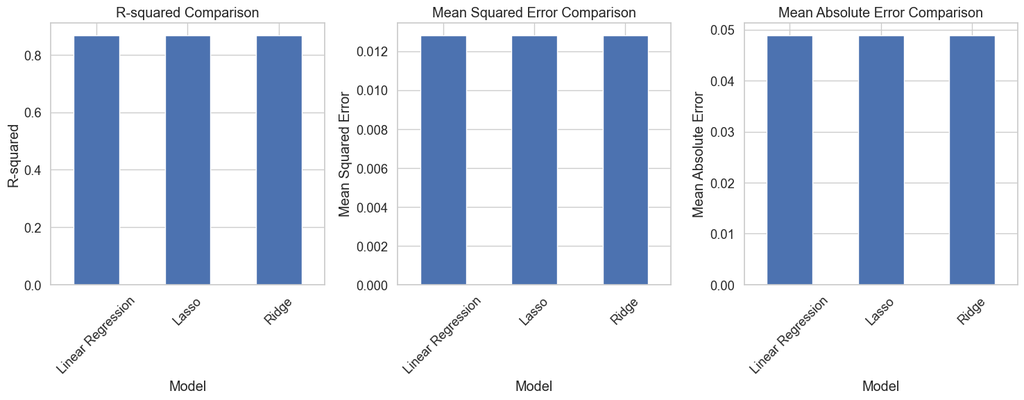

```python
# Set up the bar chart
fig, ax = plt.subplots(1, 3, figsize=(15, 6))

# Create a function for drawing the bar chart
def draw_bar_chart(column_name, ax_index, title):
    summary_table.plot(x='Model', y=column_name, kind='bar', legend=False, ax=ax[ax_index])
    ax[ax_index].set_title(title)
    ax[ax_index].set_ylabel(column_name)
    ax[ax_index].set_xlabel('Model')
    ax[ax_index].set_xticklabels(summary_table['Model'], rotation=45)

# Draw the bar charts for R-squared, Mean Squared Error, and Mean Absolute Error
draw_bar_chart('R-squared', 0, 'R-squared Comparison')
draw_bar_chart('Mean Squared Error', 1, 'Mean Squared Error Comparison')
draw_bar_chart('Mean Absolute Error', 2, 'Mean Absolute Error Comparison')

# Display the chart
plt.tight_layout()
plt.show()
```

The results you have presented show that all three models have similar performance metrics. The R-squared, Mean Squared Error (MSE), and Mean Absolute Error (MAE) are almost identical for Linear Regression, Lasso, and Ridge models. This suggests that the models are performing similarly on the test dataset.

It is not necessarily wrong, but it might be worth exploring further to see if there is any room for improvement in the model selection or feature engineering. Since the performance metrics are very close, it could be that there is not much difference in the models' ability to capture the underlying patterns in the data.

The R-squared score for the Linear Regression model is 0.87, which indicates that 87% of the variance in the target variable (offer completion) can be explained by the independent variables in the model. The closer the R-squared score is to 1, the better the model fits the data.

The MSE score for the Linear Regression model is 0.01, which indicates that on average, the predicted values are only 0.1 off from the actual values. The lower the MSE score, the better the model fits the data.

Overall, these scores suggest that the Linear Regression model is a good fit for the data and can accurately predict offer completion for starbucks customers.

# Results and Insights

In this Starbucks analysis project, one particularly interesting aspect was understanding the influence of customer demographics on offer completion rates. Analyzing how factors such as age, income, and gender affect customers' responsiveness to different types of offers provided valuable insights into how Starbucks could optimize their marketing campaigns. This task required a deep understanding of the relationships between various features and a thorough exploration of the dataset to draw meaningful conclusions.

A challenging aspect of the project was dealing with the missing and potentially incorrect data entries. We encountered missing values in the age, income, and amount columns, as well as unrealistic age entries greater than 100. Addressing these data quality issues required careful consideration of the best approach to take while ensuring the validity of our analysis. Deciding whether to drop, fill, or modify these data entries involved weighing the potential impact on the overall results and the integrity of our modeling process. This presented a difficult yet crucial aspect of the project that required both domain knowledge and data processing expertise.

# Improvement and potential problems

One area where the current implementation could be improved is in handling customers who did not view the offer but still completed it. As these customers were not directly influenced by the offer, their inclusion in the analysis might affect the model's accuracy. A potential solution would be to exclude such customers from the dataset or develop a separate model specifically for them. This would allow us to better understand the factors influencing offer completion for customers who were not exposed to the offers. Additionally, the current linear regression model could be improved by exploring more advanced machine learning techniques, such as ensemble methods or deep learning. Comparing the performance of these alternative models against the current linear regression model could provide deeper insights and potentially enhance the accuracy of our predictions, allowing Starbucks to further optimize their marketing campaigns.